# Project1

Gargiulo,Santonicola,Ambrosio

28/9/2020

Applicazione Shiny interattiva: [clicca qui](https://sgargiulo14.shinyapps.io/Project_Fasano1)

# Serie storiche: API calling

La serie storiche giornaliere delle azioni US scelte sono state reperite attraverso il servizio API offerto da [alphavantage](https://www.alphavantage.com/) e il pacchetto alphavantager, che permette con funzioni semplici di interrogare il database di alphavantage e scaricare le serie storiche desiderate.

Dopo un’elaborazione preliminare dei dati, i prezzi di chiusura si presentano come segue:

```r
knitr::kable(data[1:20,],caption = "Prezzi di chiusura", digits = 4, "pipe")
```

Prezzi di chiusura

| timestamp | AMD | LMT | MSFT | NEM | PFE | UTX |
| --- | --- | --- | --- | --- | --- | --- |
| 2019-04-17 | 27.49 | 310.50 | 121.77 | 34.18 | 39.88 | 135.79 |
| 2019-04-18 | 27.68 | 314.26 | 123.37 | 33.04 | 39.38 | 137.00 |
| 2019-04-22 | 28.18 | 315.26 | 123.76 | 32.55 | 38.98 | 136.91 |
| 2019-04-23 | 27.97 | 333.10 | 125.44 | 32.37 | 39.42 | 140.02 |
| 2019-04-24 | 28.46 | 330.12 | 125.01 | 32.20 | 39.37 | 139.59 |
| 2019-04-25 | 27.66 | 328.87 | 129.15 | 31.63 | 39.61 | 139.73 |
| 2019-04-26 | 27.88 | 328.33 | 129.89 | 31.46 | 39.97 | 140.78 |
| 2019-04-29 | 27.69 | 328.59 | 129.77 | 30.76 | 39.59 | 142.12 |
| 2019-04-30 | 27.63 | 333.33 | 130.60 | 31.06 | 40.61 | 142.61 |
| 2019-05-01 | 26.81 | 331.85 | 127.88 | 30.32 | 40.77 | 141.58 |
| 2019-05-02 | 28.29 | 332.55 | 126.21 | 30.10 | 41.01 | 139.80 |
| 2019-05-03 | 28.22 | 334.07 | 128.90 | 30.22 | 41.39 | 141.63 |
| 2019-05-06 | 27.42 | 335.72 | 128.15 | 29.94 | 41.65 | 140.20 |
| 2019-05-07 | 26.66 | 330.90 | 125.52 | 30.72 | 40.83 | 135.44 |
| 2019-05-08 | 27.09 | 334.18 | 125.51 | 30.20 | 40.95 | 137.07 |
| 2019-05-09 | 27.21 | 339.36 | 125.50 | 29.93 | 40.64 | 136.86 |
| 2019-05-10 | 27.96 | 341.35 | 127.13 | 30.15 | 40.72 | 137.17 |
| 2019-05-13 | 26.24 | 335.37 | 123.35 | 30.91 | 40.57 | 131.96 |
| 2019-05-14 | 27.32 | 336.17 | 124.73 | 30.83 | 40.66 | 133.98 |
| 2019-05-15 | 27.58 | 334.15 | 126.02 | 30.69 | 41.15 | 133.98 |

# Log-rendimenti e statistiche

La sequenza di rendimenti target è la seguente (l’output di cui sotto si limita solo ai primi 10 elementi):

```r
lo.tar=0.005
up.tar=0.5
target <- seq(lo.tar,up.tar,by=0.005)
target[1:10]
```

```
##  [1] 0.005 0.010 0.015 0.020 0.025 0.030 0.035 0.040 0.045 0.050
```

Essa va da 0.005 a 0.5, in step di 0.005.

A questo punto possiamo calcolare i log-rendimenti giornalieri.

```r
R <- diff(as.matrix(log(data[,2:ncol(data)])))
time <- data[,1]
R <- data.frame(time=time[-1],R)
knitr::kable(R[1:10,],caption = "Log-rendimenti", digits = 4, "pipe")
```

Log-rendimenti

| time | AMD | LMT | MSFT | NEM | PFE | UTX |
| --- | --- | --- | --- | --- | --- | --- |
| 2019-04-18 | 0.0069 | 0.0120 | 0.0131 | -0.0339 | -0.0126 | 0.0089 |
| 2019-04-22 | 0.0179 | 0.0032 | 0.0032 | -0.0149 | -0.0102 | -0.0007 |
| 2019-04-23 | -0.0075 | 0.0550 | 0.0135 | -0.0055 | 0.0112 | 0.0225 |
| 2019-04-24 | 0.0174 | -0.0090 | -0.0034 | -0.0053 | -0.0013 | -0.0031 |
| 2019-04-25 | -0.0285 | -0.0038 | 0.0326 | -0.0179 | 0.0061 | 0.0010 |
| 2019-04-26 | 0.0079 | -0.0016 | 0.0057 | -0.0054 | 0.0090 | 0.0075 |
| 2019-04-29 | -0.0068 | 0.0008 | -0.0009 | -0.0225 | -0.0096 | 0.0095 |
| 2019-04-30 | -0.0022 | 0.0143 | 0.0064 | 0.0097 | 0.0254 | 0.0034 |
| 2019-05-01 | -0.0301 | -0.0044 | -0.0210 | -0.0241 | 0.0039 | -0.0072 |
| 2019-05-02 | 0.0537 | 0.0021 | -0.0131 | -0.0073 | 0.0059 | -0.0127 |

Calcoliamo rendimenti attesi $\mu$ e matrice $\Sigma$

```r
R <- diff(as.matrix(log(data[,2:ncol(data)])))
e.r <- matrix(apply(R,2,mean)) #Vettore dei rendimenti attesi
rownames(e.r) <- names(data[2:length(data)])
colnames(e.r) <- "mu"
s.d <-matrix(apply(R,2,sd)) # Deviazione standard rendimenti
Sig <- cov(R) #Matrice varianze covarianze (S nella parte teorica allegata)

knitr::kable(e.r,caption = "mu", digits = 4, "pipe")
```

mu

|  | mu |
| --- | --- |
| AMD | 0.0029 |
| LMT | 0.0006 |
| MSFT | 0.0015 |
| NEM | 0.0016 |
| PFE | -0.0003 |
| UTX | -0.0023 |

```r
knitr::kable(Sig,caption = "var-cov", digits = 8, "pipe")
```

var-cov

|  | AMD | LMT | MSFT | NEM | PFE | UTX |
| --- | --- | --- | --- | --- | --- | --- |
| AMD | 0.00130114 | 0.00029699 | 0.00056485 | 0.00021049 | 0.00026718 | 0.00043842 |
| LMT | 0.00029699 | 0.00049298 | 0.00030227 | 0.00009003 | 0.00025357 | 0.00041327 |
| MSFT | 0.00056485 | 0.00030227 | 0.00055575 | 0.00011539 | 0.00025263 | 0.00039575 |
| NEM | 0.00021049 | 0.00009003 | 0.00011539 | 0.00059609 | 0.00005288 | 0.00016283 |
| PFE | 0.00026718 | 0.00025357 | 0.00025263 | 0.00005288 | 0.00034774 | 0.00021739 |
| UTX | 0.00043842 | 0.00041327 | 0.00039575 | 0.00016283 | 0.00021739 | 0.00165818 |

Utilizziamo poi la funzione solve() per calcolare l’inversa della matrice $\Sigma$ e creiamo altresì un vettore unitario con lunghezza pari al numero di società presenti nel portafoglio.

```r
S.inv <- solve(Sig)   #Inversa della Matrice delle varianze e covarianze
unit <- matrix(rep(1,length(e.r))) #Vettore unitario di lunghezza pari al
                                    #numero di STOCK
```

# Calcolo vettore ottimale di pesi

Adesso procediamo a calcolare i coefficienti $a,b,c$ necessari per ottenere il vettore di pesi ottimale $w^*$:

$$a = \mu^{'} \textbf{S}^{-1} \mu\$$
$$b = \mu^{'} \textbf{S}^{-1} \textbf{1}$$
$$c = \textbf{1}^{'} \textbf{S}^{-1} \textbf{1}$$

```r
e.r <- matrix(apply(R,2,mean))
A<-t(e.r)%*%S.inv%*%e.r
B<-t(e.r)%*%S.inv%*%unit
C<-t(unit)%*%S.inv%*%unit
data.frame(A=A,B=B,C=C)
```

```
##           A        B        C
## 1 0.0234492 2.184202 4286.679
```

Fissato allora un valore del rendimento target possiamo procedere al calcolo del vettore $w^*$, che minimizza la varianza del portafoglio dato un livello del rendimento target.

$$w^* = \textbf{S}^{-1} \frac{
(mc-b)\mu \ + \ (a-\mu b)\textbf{1}
}{
ac-b^2
}$$
Possiamo adesso calcolare la varianza corrispondente ad un portafoglio formato dai titoli con pesi pari a $w^*$

$$\sigma_{R}^2 = w^{*'} \textbf{S} w^*$$
Scegliamo ad esempio $m=0.05$ e calcoliamo il vettore dei pesi con la corrispondente varianza:

```r
m = 0.05 #Fisso rendimento target

num <- e.r%*%(m*C-B)+unit%*%(A-m*B)   #Numeratore della formula per il
                                      #calcolo del vettore dei pesi

den <- A*C - B^2                      #Denominatore

w.star <- S.inv%*%num%*%(1/den)    #Vettore dei pesi

var.star <- t(w.star)%*%Sig%*%w.star #Calcoliamo la varianza del portafoglio
                                     #dati i pesi ottimali w*

colnames(w.star)="weights"

res <- list("weights" =w.star,
            "variance"=var.star)
res
```

```
## $weights
##         weights
## AMD    4.377913
## LMT    5.805366
## MSFT   6.365009
## NEM    3.826951
## PFE  -12.978931
## UTX   -6.396308
##
## $variance
##           [,1]
## [1,] 0.1098893
```

La procedura di cui sopra è stata applicata per ogni livello della sequenza di rendimenti target attraverso una funzione personalizzata in R mediante l’utilizzo di un for loop. La funzione è la seguente:

```r
calc <- function(data,up.tar=0.5,lo.tar=0.005){

  target <- seq(lo.tar,up.tar,by=0.005)  # Crea la sequenza di rendimenti target
R <- diff(as.matrix(log(data[,2:ncol(data)]))) #Rendimenti daily logaritmici
                                                #(r nel file di teoria)

e.r <- matrix(apply(R,2,mean)) #Vettore dei rendimenti attesi

s.d <-matrix(apply(R,2,sd)) # Deviazione standard rendimenti

Sig <- cov(R) #Matrice varianze covarianze
              #(S nella parte teorica allegata)

S.inv <- solve(Sig)   #Inversa della Matrice delle varianze e covarianze

unit <- matrix(rep(1,length(e.r))) #Vettore unitario di lunghezza
                                   # pari al numero di azioni presenti




#Coefficienti a,b,c
A<-t(e.r)%*%S.inv%*%e.r
B<-t(e.r)%*%S.inv%*%unit
C<-t(unit)%*%S.inv%*%unit


#res <- matrix(0,ncol=ncol(data)-1,nrow=length(target))

all.w <- list() #Lista vuota ove confluiranno i risultati del for loop

var.vec <- vector("numeric",length=length(target))
#vettore vuoto dove confluiranno i risultati del for loop


# FOR LOOP

for (i in 1:length(target)){

m <- target[i] #Rendimento target


num <- e.r%*%(m*C-B)+unit%*%(A-m*B) #Numeratore della formula per il calcolo
                                    #del vettore dei pesi

den <- A*C - B^2                        #Denominatore

w.star <- S.inv%*%num%*%(1/den)    #Vettore dei pesi


var.star <- t(w.star)%*%Sig%*%w.star
#Calcoliamo la varianza del portafoglio dati i pesi ottimali w*


res <- list("weights" =w.star,
            "variance"=var.star)

all.w[[i]] <- res
# Conterrà i pesi ottimali e la varianza per ogni possibile rendimento target


var.vec[i] <- var.star
#Conterrà solo la varianza per ogni possibile rendimento target

#t(w.star)%*%e.r    #prova che il vettore ottimale dei pesi trasposto * per i                             #rendimenti attesi, è pari a 0.01, cioè il rendimento target
#sum(w.star)      #prova che la somma dei pesi è 1
#t(w.star)%*%unit   #prova che la somma dei pesi è 1
}

plot.data <- cbind(target,var.vec) #Creare dataframe da cui plottare grafico

names(all.w) <- as.character(target) #Associare nomi alla lista

invisible(list("all.w"=all.w,"plot"=plot.data))}
```

La funzione permette anche di caratterizzare l’intervallo entro cui calcolare i rendimenti target.

L’output della funzione è una lista che comprende a sua volta una lista e un data.frame. La prima contiene il vettore $w^*$ e la rispettiva varianza per ogni livello del rendimento target. Il data.frame, invece, serve per il grafico. Infatti contiene sia i livelli target sia la varianza minima corrispondente associata a tale livello.

# Plot

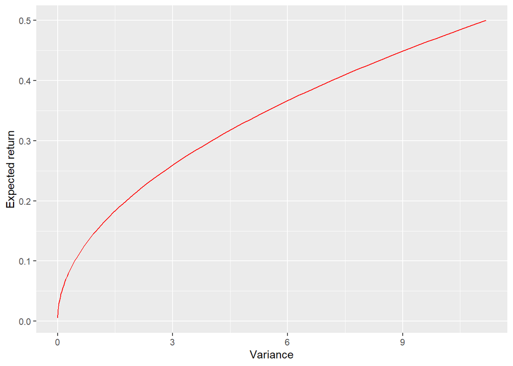

```r
output <- calc(data)
xx <- as.data.frame(output[["plot"]])

xxx <- matrix(0,nrow=6,ncol=2)

for(i in 1:6){

  xxx[i,1] = mean(R[,i])
  xxx[i,2] = sd(R[,i])^2

}
xxx <- as.data.frame(xxx)
pick <- c("AMD","LMT","MSFT","NEM","PFE","UTX")
colnames(xxx) <- c("mu","sig")
rownames(xxx) <- pick


ggplot(data=xx, aes(x=var.vec, y=target))+geom_line(color="red")+
  xlab("Variance")+ylab("Expected return")
```

# Output

Infine abbiamo costruito una tabella che sintetizza al meglio i risultati ottenuti.

```r
df.pick <- as.matrix(data[,pick])


dat <- as.data.frame(output[["plot"]])

weig <- array(NA, dim= c(length(pick),1,length(output$all.w))) #creiamo array
#vuoto in cui estrarre il vettore dei pesi per ogni livello del rend. target

for(i in 1:length(output$all.w)){

  weig[,1,i] <- output %>% extract2(c(1,i,1)) #con extract2 estraggo gli elementi
  #dalla lista e li salvo nella posizione i-esima dell'array

}

weig.f <- adply(weig, c(2,3))[,c(-1,-2)] #trasforma l'array in un data.frame

names(weig.f) <- pick

dat.f <- cbind(dat,weig.f) #Uniamo i due data.frame

dat.f[,c(-1)] <- round(dat.f[,c(-1)], digits = 4) #Arrotondiamo i valori dei pesi

knitr::kable(dat.f,caption = "Risultati","pipe") #Creo tabella
```

Risultati

| target | var.vec | AMD | LMT | MSFT | NEM | PFE | UTX |
| --- | --- | --- | --- | --- | --- | --- | --- |
| 0.005 | 0.0011 | 0.3497 | 0.6386 | 0.6839 | 0.6431 | -0.7351 | -0.5802 |
| 0.010 | 0.0043 | 0.7973 | 1.2127 | 1.3152 | 0.9968 | -2.0956 | -1.2265 |
| 0.015 | 0.0096 | 1.2449 | 1.7868 | 1.9464 | 1.3506 | -3.4560 | -1.8727 |
| 0.020 | 0.0172 | 1.6925 | 2.3609 | 2.5776 | 1.7044 | -4.8164 | -2.5189 |
| 0.025 | 0.0271 | 2.1400 | 2.9350 | 3.2089 | 2.0581 | -6.1768 | -3.1652 |
| 0.030 | 0.0392 | 2.5876 | 3.5090 | 3.8401 | 2.4119 | -7.5372 | -3.8114 |
| 0.035 | 0.0535 | 3.0352 | 4.0831 | 4.4713 | 2.7657 | -8.8977 | -4.4576 |
| 0.040 | 0.0701 | 3.4828 | 4.6572 | 5.1025 | 3.1194 | -10.2581 | -5.1038 |
| 0.045 | 0.0889 | 3.9303 | 5.2313 | 5.7338 | 3.4732 | -11.6185 | -5.7501 |
| 0.050 | 0.1099 | 4.3779 | 5.8054 | 6.3650 | 3.8270 | -12.9789 | -6.3963 |
| 0.055 | 0.1332 | 4.8255 | 6.3794 | 6.9962 | 4.1807 | -14.3394 | -7.0425 |
| 0.060 | 0.1587 | 5.2731 | 6.9535 | 7.6275 | 4.5345 | -15.6998 | -7.6888 |
| 0.065 | 0.1864 | 5.7206 | 7.5276 | 8.2587 | 4.8883 | -17.0602 | -8.3350 |
| 0.070 | 0.2164 | 6.1682 | 8.1017 | 8.8899 | 5.2420 | -18.4206 | -8.9812 |
| 0.075 | 0.2487 | 6.6158 | 8.6758 | 9.5212 | 5.5958 | -19.7810 | -9.6275 |
| 0.080 | 0.2831 | 7.0634 | 9.2499 | 10.1524 | 5.9496 | -21.1415 | -10.2737 |
| 0.085 | 0.3198 | 7.5109 | 9.8239 | 10.7836 | 6.3033 | -22.5019 | -10.9199 |
| 0.090 | 0.3588 | 7.9585 | 10.3980 | 11.4149 | 6.6571 | -23.8623 | -11.5661 |
| 0.095 | 0.4000 | 8.4061 | 10.9721 | 12.0461 | 7.0108 | -25.2227 | -12.2124 |
| 0.100 | 0.4434 | 8.8537 | 11.5462 | 12.6773 | 7.3646 | -26.5831 | -12.8586 |
| 0.105 | 0.4890 | 9.3012 | 12.1203 | 13.3085 | 7.7184 | -27.9436 | -13.5048 |
| 0.110 | 0.5369 | 9.7488 | 12.6943 | 13.9398 | 8.0721 | -29.3040 | -14.1511 |
| 0.115 | 0.5871 | 10.1964 | 13.2684 | 14.5710 | 8.4259 | -30.6644 | -14.7973 |
| 0.120 | 0.6395 | 10.6439 | 13.8425 | 15.2022 | 8.7797 | -32.0248 | -15.4435 |
| 0.125 | 0.6941 | 11.0915 | 14.4166 | 15.8335 | 9.1334 | -33.3853 | -16.0898 |
| 0.130 | 0.7509 | 11.5391 | 14.9907 | 16.4647 | 9.4872 | -34.7457 | -16.7360 |
| 0.135 | 0.8100 | 11.9867 | 15.5647 | 17.0959 | 9.8410 | -36.1061 | -17.3822 |
| 0.140 | 0.8714 | 12.4342 | 16.1388 | 17.7272 | 10.1947 | -37.4665 | -18.0285 |
| 0.145 | 0.9349 | 12.8818 | 16.7129 | 18.3584 | 10.5485 | -38.8269 | -18.6747 |
| 0.150 | 1.0007 | 13.3294 | 17.2870 | 18.9896 | 10.9023 | -40.1874 | -19.3209 |

[output cut: 70 more lines]